# Salesforce

Innovation strategy, what have we done and what’s next?

Maria Briones

Riccardo Dondi

Sayantan Mandal

[figure not shown]

Leading CRM platform offering cloud-based applications (Sales, Service, Marketing, Commerce) that help businesses manage customer interactions across the full lifecycle.

- Subscription-based model and professional services.
- Increasingly centered on data and AI, with Data Cloud unifying customer information.
- Enable autonomous AI agents—making AI a core layer across all Salesforce products.

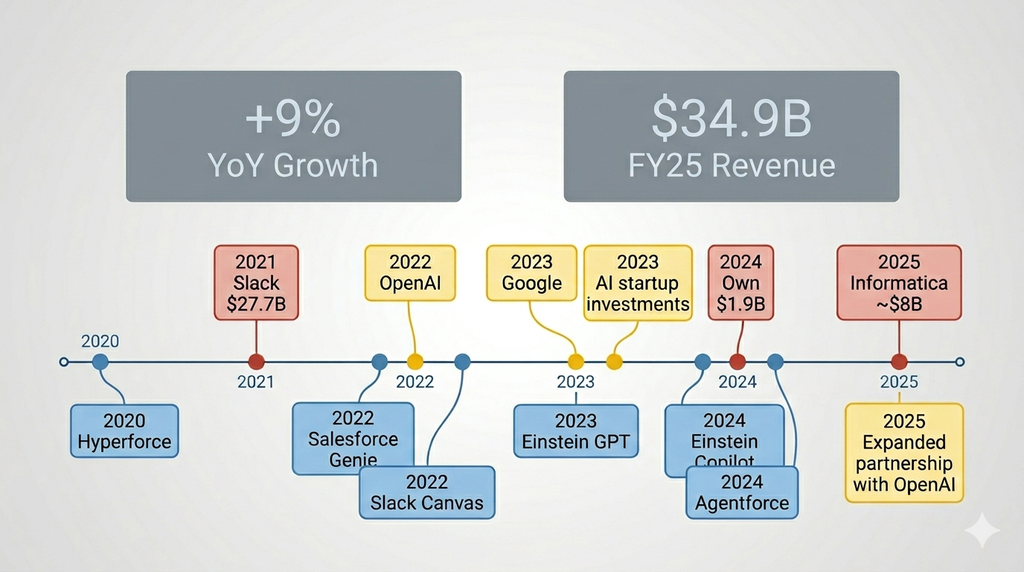

We’ve been moving from an agressive Buy strategy → to a Build + Partner strategy. Our focus moved from acquiring platforms to owning the AI orchestration layer

## Why?

On early 2021 we had to gaps preventing us from leading the industry:

- **Technology gap**:
  - Lacked large language model capability.
  - Data layers were not unified across systems.
- **Talent gap**:
  - Lack of AI expertise to build one

## From BUY → BUILD + PARTNER

**2020–2022**: Aggressive Buy Strategy

- Goal: Expand the platform horizontally through **strategic acquisitions**.

- Goal: Let partners provide the foundation models.
- Subsequent pivot to **internal R&D** with **strategic partnership** to deliver generative AI.

## How did this reinforce our strategy?

This startegy allowed us to **remain coherent with our core bussiness** activities and at the same time reinforce our position as a leader in the CRM space by two main channels:

- We expanded the software seats across our ecosystem.
- Made them *AI-capable* (more efficient, more aware, more understanding) rather than replacing them.

## What’s next?

As we have recently secured our strategic partnership with OpenAI, and with the technology gaps been fully adressed, Salesforce should move forward to:

- **Build** new products and integrating them into our platform to deliver aggregate value. This is, reinforce our product ecosystem and make it more difficult for competitors to replicate our offering.
- This implies a strong **reinforcement to our R&D Units and our Corporate Incubator**.

[figure not shown]

**Thank you!**

Maria Briones, Riccardo Dondi, Sayantan Mandal.